# Tutorial 05 — Phage Pharmacokinetics

**Prerequisites:** Tutorials 01–04

In tutorials 01–04, phage doses were applied directly to the infection site (`P`). This is appropriate for local delivery (topical application, nebulisation into a lung cavity). When phage are given **intravenously** (IV) — the route used in most systemic phage therapy — they must first distribute from the **blood** to the **infection site**, a process governed by pharmacokinetics (PK).

**What you will learn**

1. Why IV phage PK is needed and what the two compartments represent
2. Effect-compartment mode: blood concentration drives site delivery (one-way)
3. Mass-conserving mode (`Vi`): bidirectional; total phage count conserved
4. `k_elim`: phage clearance from blood (innate immune system, filtration)
5. `k_back`: lysis-driven phage re-entry into blood — why infected patients maintain higher blood titres than uninfected controls
6. Peripheral tissue compartment (`k12`, `k21`)
7. How to choose between the two modes

## 1 Imports and shared bacterial model

```python
import numpy as np
import matplotlib.pyplot as plt

from pbisim import (ModelBuilder, PBIModel, solve_ode,
                    PhagePKConfig, DoseEvent, DoseSchedule)

# Single-strain bacterial model — same parameters as Tutorial 01
# (no phage PK yet; we will add PK layer progressively)
BASE = (
    ModelBuilder(n_bacteria=1, n_phages=1, n_latent=5)
    .with_growth_rates(1.0, bacteria_to_resource_ratio=1e9)
    .with_phage_params(
        adsorption_rates    = 2e-9,   # mL h⁻¹
        burst_sizes         = 50.0,   # PFU per lysed cell
        latent_periods      = 0.5,    # h
        phage_decay_rates   = 0.1,    # h⁻¹ intrinsic phage decay at site
    )
    .with_nutrient(monod_constant=0.3, recycle_fraction=0.0)
)

B0 = np.array([1e7])    # initial bacteria (cells/mL)
T_END = 72.0            # h

# Phage dose as AMOUNT to central compartment (Pc = phage count in blood)
# For effect-compartment and Vi modes:  DoseEvent adds to Pc.
# For direct mode (no PK):             DoseEvent adds to P directly.
DOSE_AMOUNT = 1e12      # phage administered IV (total phage count)
```

## 2 Mode 0 — Direct dosing (no PK, local delivery)

Without `PhagePKConfig`, a dose event with `target="phage"` adds directly to the infection-site concentration `P` (PFU / mL). This is appropriate for phage applied locally (wound irrigation, inhaled aerosol).

The infection site immediately has high phage density → rapid killing from t = 0.

```python
# Direct: dose (in PFU/mL) goes straight to P at t = 0
direct_dose_mL = 2e8    # PFU/mL at site (equivalent to 1e12 phage in 5L blood vol)
sched_direct = DoseSchedule([
    DoseEvent(time=0, amount=direct_dose_mL, target="phage", index=0)
])
cfg_direct = BASE.with_dose_schedule(sched_direct).build()
res_direct = solve_ode(
    PBIModel(cfg_direct, initial_B=B0, initial_P=np.array([0.0])),
    t_end=T_END, dt=0.25,
)
print(f"Peak site phage (direct):  {res_direct.get('P0').max():.2e} PFU/mL at t=0+")
print(f"Bacteria at 48h (direct):  {res_direct.get('B0')[-2]:.2e} cells/mL")
```

```
Peak site phage (direct):  2.83e+09 PFU/mL at t=0+
Bacteria at 48h (direct):  1.30e-10 cells/mL
```

## 3 Mode 1 — Effect-compartment PK (`Vi = None`)

With `PhagePKConfig` and `Vi = None` (default), the central compartment `Pc` (phage count in blood) drives delivery to the infection site via:

```
dP/dt  += k_in · Cc  −  k_out · P       Cc = Pc / Vc (blood concentration)
dPc/dt  = R_dose(t)  −  k_elim · Pc     (no feedback from P back to Pc)
```

**Biological interpretation of parameters:**

| Parameter | Typical value | Biological meaning |
| --- | --- | --- |
| `k_elim` | 0.05–0.3 h⁻¹ | Blood clearance: innate immunity, liver, kidney; phage half-life ≈ 3–14 h |
| `k_in` | 0.1–1 h⁻¹ | Rate at which blood phage concentration drives accumulation at the site |
| `k_out` | 0.1–1 h⁻¹ | Site clearance: local innate immunity, phage decay |
| `Vc` | 5 L | Blood volume (adult); scales the blood concentration Cc = Pc/Vc |

At steady state (no biology): `P* = (k_in / k_out) · Cc`

```python
ppk_effect = PhagePKConfig(
    n_phages    = 1,
    k_elim      = np.array([0.1]),    # h⁻¹ — phage half-life in blood ≈ 7h
    k_in        = np.array([0.3]),    # h⁻¹ — delivery rate to infection site
    k_out       = np.array([0.2]),    # h⁻¹ — clearance at infection site
    Vc          = np.array([5000.0]), # mL  — adult blood volume (5 L)
)

# Dose: add DOSE_AMOUNT phage to Pc (blood) at t=0
sched_iv = DoseSchedule([
    DoseEvent(time=0, amount=DOSE_AMOUNT, target="phage", index=0)
])
cfg_effect = BASE.with_phage_pk(ppk_effect).with_dose_schedule(sched_iv).build()
res_effect = solve_ode(
    PBIModel(cfg_effect, initial_B=B0,
             initial_P=np.array([0.0]),
             initial_Pc=np.array([0.0])),   # phage enters via dose schedule
    t_end=T_END, dt=0.25,
)

Cc_effect = res_effect.get("Pc0") / ppk_effect.Vc[0]    # blood concentration
print(f"Peak blood conc (Cc):  {Cc_effect.max():.2e} PFU/mL at t=0+")
print(f"Peak site conc (P):    {res_effect.get('P0').max():.2e} PFU/mL")
print(f"Bacteria at 48h:       {res_effect.get('B0')[-2]:.2e} cells/mL")
```

```
Peak blood conc (Cc):  2.00e+08 PFU/mL at t=0+
Peak site conc (P):    3.43e+09 PFU/mL
Bacteria at 48h:       3.48e+04 cells/mL
```

## 4 Direct vs effect-compartment: route of delivery shapes site kinetics

**Direct dosing** delivers phage immediately to the infection site at full therapeutic concentration. There is no reservoir — once those phage adsorb or decay, they are gone — but the initial concentration can be very high, enabling rapid bacterial killing before resistance can develop.

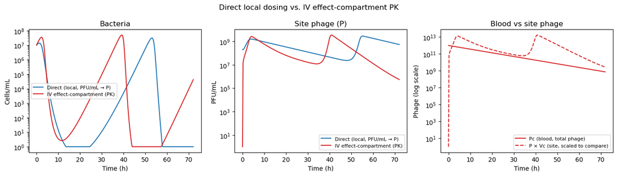

```python
fig, axes = plt.subplots(1, 3, figsize=(14, 4))

for (res, color, label) in [
    (res_direct, "C0", "Direct (local, PFU/mL → P)"),
    (res_effect, "C3", "IV effect-compartment (PK)"),
]:
    axes[0].semilogy(res.time, np.maximum(res.get("B0"), 1),
                     color=color, label=label)
    axes[1].semilogy(res.time, np.maximum(res.get("P0"), 1),
                     color=color, label=label)

axes[2].semilogy(res_effect.time,
                 np.maximum(res_effect.get("Pc0"), 1),
                 "C3", label="Pc (blood, total phage)")
axes[2].semilogy(res_effect.time,
                 np.maximum(res_effect.get("P0") * ppk_effect.Vc[0], 1),
                 "C3--", label="P × Vc (site, scaled to compare)")

for ax, title, ylabel in zip(
    axes,
    ["Bacteria", "Site phage (P)", "Blood vs site phage"],
    ["Cells/mL", "PFU/mL", "Phage (log scale)"],
):
    ax.set(xlabel="Time (h)", ylabel=ylabel, title=title)
    ax.legend(fontsize=8)

plt.suptitle("Direct local dosing vs. IV effect-compartment PK")
plt.tight_layout()
plt.show()
```

## 5 Mass-conserving mode (`Vi`) — bidirectional transfer

When `Vi` is provided, the k_in/k_out transfer terms are bidirectional and **conserve phage between the two compartments**:

```
dPc/dt += −k_in · Pc  +  k_out · P · Vi    (transfer terms only)
  dP/dt +=  k_in · Pc / Vi  −  k_out · P
```

The full equations also include `−k_elim · Pc` (blood clearance) and, once bacteria are present, the lysis burst adds phage directly to `P`. Therefore `Pc + P · Vi` is **not** a strict constant in a biological simulation:

- **k_elim** removes phage from blood → total decreases
- **Phage replication** (lysis burst at infection site) adds phage to P → total increases

The "mass-conserving" label refers to the bidirectional transfer geometry, not to global phage count conservation.

Use this mode when the infection-site volume is known (e.g., a 5–20 mL abscess cavity) and you need the two-way exchange to be physically accurate. The effect-compartment approximation is appropriate when site volume is negligible relative to blood volume or is uncertain.

**Steady-state site concentration (no biology, no k_elim):** `P* = k_in · Pc / (k_out · Vi)`

**Parameter calibration warning:** `k_in` has different physical meanings in the two modes.

| Mode | Site delivery rate | Steady-state P |
| --- | --- | --- |
| Effect compartment | `k_in · Pc/Vc` | `(k_in/k_out) · Pc/Vc` |
| Mass-conserving (Vi) | `k_in · Pc/Vi` | `(k_in/k_out) · Pc/Vi` |

With `Vc = 5000 mL` and `Vi = 20 mL`, using the **same** `k_in = 0.3` would deliver 250× more phage to the site in Vi mode — making the comparison unfair. To match the same initial delivery rate, scale by the volume ratio: `k_in_vi = k_in_eff × (Vi / Vc)`

```
k_in (effect-comp) = 0.3000,  k_in_vi (Vi-mode, scaled) = 0.001200
Initial total phage (t≈0): 9.753e+11
Final   total phage (t=72.0h): 4.689e+09
Change: -99.5%  (expected non-zero: k_elim drains blood; lysis adds phage to P)
```

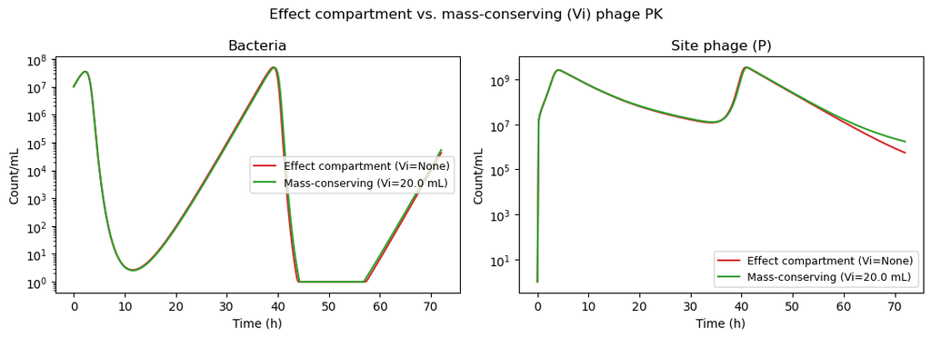

```python
Vi_val = 20.0   # mL — 20 mL abscess cavity

# Scale k_in so that the initial phage delivery rate (PFU/mL/h at site)
# matches the effect-compartment mode.
# Effect-comp delivers k_in * Pc/Vc; Vi-mode delivers k_in * Pc/Vi.
# Setting k_in_vi = k_in_eff * Vi/Vc equalises both rates.
k_in_vi = ppk_effect.k_in[0] * Vi_val / ppk_effect.Vc[0]   # 0.3 × 20/5000 = 0.0012
print(f"k_in (effect-comp) = {ppk_effect.k_in[0]:.4f},  "
      f"k_in_vi (Vi-mode, scaled) = {k_in_vi:.6f}")

ppk_vi = PhagePKConfig(
    n_phages = 1,
    k_elim   = np.array([0.1]),
    k_in     = np.array([k_in_vi]),   # scaled for equivalent phage delivery rate
    k_out    = np.array([0.2]),
    Vc       = np.array([5000.0]),
    Vi       = np.array([Vi_val]),     # infection-site volume (mL)
)
cfg_vi = BASE.with_phage_pk(ppk_vi).with_dose_schedule(sched_iv).build()
res_vi = solve_ode(
    PBIModel(cfg_vi, initial_B=B0,
             initial_P=np.array([0.0]),
             initial_Pc=np.array([0.0])),
    t_end=T_END, dt=0.25,
)

# Verify conservation: Pc + P*Vi should be constant after dose at t=0+
Pc_vi = res_vi.get("Pc0")
P_vi  = res_vi.get("P0")
total = Pc_vi + P_vi * Vi_val
print(f"Initial total phage (t≈0): {total[1]:.3e}")
print(f"Final   total phage (t={T_END}h): {total[-1]:.3e}")
pct = (total[-1] - total[1]) / total[1] * 100
print(f"Change: {pct:+.1f}%  (expected non-zero: k_elim drains blood; lysis adds phage to P)")

fig, axes = plt.subplots(1, 2, figsize=(11, 4))
for (res, color, label) in [
    (res_effect, "C3", "Effect compartment (Vi=None)"),
    (res_vi,     "C2", f"Mass-conserving (Vi={Vi_val} mL)"),
]:
    axes[0].semilogy(res.time, np.maximum(res.get("B0"), 1),  color=color, label=label)
    axes[1].semilogy(res.time, np.maximum(res.get("P0"), 1),  color=color, label=label)
for ax, title in zip(axes, ["Bacteria", "Site phage (P)"]):
    ax.set(xlabel="Time (h)", ylabel="Count/mL", title=title)
    ax.legend(fontsize=9)
plt.suptitle("Effect compartment vs. mass-conserving (Vi) phage PK")
plt.tight_layout()
plt.show()
```

## 6 `k_back` — lysis-driven phage re-entry into blood

A striking clinical observation: phage concentrations in the blood of infected patients treated with IV phage are **higher and persist longer** than in uninfected controls given the same dose. The explanation is that phage released by bacterial lysis at the infection site spill back into the bloodstream.

`k_back` (h⁻¹) adds a drain from `P` back to blood:

```
dP/dt  −= k_back · P
dPc/dt += k_back · P · Vi    (mass-conserving with Vi)
```

The spill-back rate is proportional to the site phage concentration, which grows when bacteria are actively being lysed. High `k_back` therefore **elevates and sustains blood titres** throughout the therapeutic period, while slightly reducing site concentration.

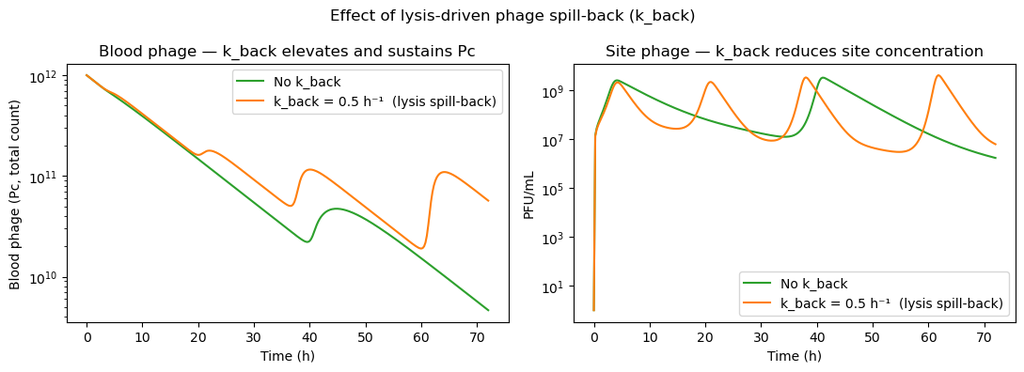

```python
ppk_kback = PhagePKConfig(
    n_phages = 1,
    k_elim   = np.array([0.1]),
    k_in     = np.array([k_in_vi]),   # same scaled k_in as ppk_vi
    k_out    = np.array([0.2]),
    Vc       = np.array([5000.0]),
    Vi       = np.array([Vi_val]),
    k_back   = np.array([0.5]),        # h⁻¹ — lysis-driven spill-back
)
cfg_kb = BASE.with_phage_pk(ppk_kback).with_dose_schedule(sched_iv).build()
res_kb = solve_ode(
    PBIModel(cfg_kb, initial_B=B0,
             initial_P=np.array([0.0]),
             initial_Pc=np.array([0.0])),
    t_end=T_END, dt=0.25,
)

fig, axes = plt.subplots(1, 2, figsize=(11, 4))
for (res, color, label) in [
    (res_vi,  "C2", "No k_back"),
    (res_kb,  "C1", "k_back = 0.5 h⁻¹  (lysis spill-back)"),
]:
    axes[0].semilogy(res.time, np.maximum(res.get("Pc0"), 1),  color=color, label=label)
    axes[1].semilogy(res.time, np.maximum(res.get("P0"),  1),  color=color, label=label)
axes[0].set(xlabel="Time (h)", ylabel="Blood phage (Pc, total count)",
            title="Blood phage — k_back elevates and sustains Pc")
axes[1].set(xlabel="Time (h)", ylabel="PFU/mL",
            title="Site phage — k_back reduces site concentration")
for ax in axes: ax.legend()
plt.suptitle("Effect of lysis-driven phage spill-back (k_back)")
plt.tight_layout()
plt.show()
```

## 7 `k_in / k_out` ratio — the site-to-blood equilibrium

At pseudo-steady state (slow Pc depletion), site concentration approaches: `P* ≈ (k_in / k_out) · Pc / Vi`

A **high k_in/k_out ratio** concentrates phage at the site (favourable for deep-tissue or biofilm infections). A **low ratio** means phage are cleared from the site faster than they are delivered — equivalent to a short effective half-life at the site.

Biologically, `k_out` reflects local innate immune clearance and mucociliary transport; `k_in` depends on tissue perfusion and phage diffusivity.

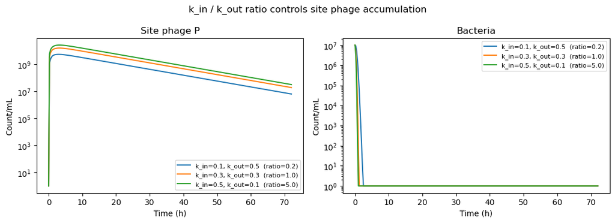

```python
ratios = [(0.1, 0.5, "C0"), (0.3, 0.3, "C1"), (0.5, 0.1, "C2")]

fig, axes = plt.subplots(1, 2, figsize=(11, 4))
for k_in, k_out, color in ratios:
    ppk = PhagePKConfig(
        n_phages=1, k_elim=np.array([0.1]),
        k_in=np.array([k_in]), k_out=np.array([k_out]),
        Vc=np.array([5000.0]), Vi=np.array([Vi_val]),
    )
    cfg = BASE.with_phage_pk(ppk).with_dose_schedule(sched_iv).build()
    res = solve_ode(
        PBIModel(cfg, initial_B=B0, initial_P=np.array([0.0]),
                 initial_Pc=np.array([0.0])),
        t_end=T_END, dt=0.25,
    )
    lbl = f"k_in={k_in}, k_out={k_out}  (ratio={k_in/k_out:.1f})"
    axes[0].semilogy(res.time, np.maximum(res.get("P0"),  1), color=color, label=lbl)
    axes[1].semilogy(res.time, np.maximum(res.get("B0"),  1), color=color, label=lbl)

for ax, title in zip(axes, ["Site phage P", "Bacteria"]):
    ax.set(xlabel="Time (h)", ylabel="Count/mL", title=title)
    ax.legend(fontsize=8)
plt.suptitle("k_in / k_out ratio controls site phage accumulation")
plt.tight_layout()
plt.show()
```

## 8 Peripheral tissue distribution — 3-compartment PK

When phage are given IV they do not distribute only to the infection site. The **reticuloendothelial system** (liver, spleen, kidney, lung capillaries) rapidly sequesters circulating phage, creating a **peripheral tissue** compartment `Pp` that exchanges phage with the blood but does **not** contribute directly to infection-site delivery.

Activate the peripheral compartment by passing `k12` and `k21` arrays to `PhagePKConfig`. Both must be provided together (or both `None`):

```
dPc/dt = R(t) − k_elim·Pc  −  k12·Pc  +  k21·Pp   [± Vi-mode transfer]
dPp/dt =                       k12·Pc  −  k21·Pp
```

The peripheral compartment is **independent** of the infection-site mode (`Vi=None` or `Vi=array`): `Pp` buffers blood concentration but phage in `Pp` cannot reach `P` directly.

| Parameter | Typical value | Biological meaning |
| --- | --- | --- |
| `k12` | 0.3–0.8 h⁻¹ | Rapid distribution from blood to RES tissues |
| `k21` | 0.05–0.2 h⁻¹ | Slow redistribution from tissues back to blood |

```
has_peripheral: True
```

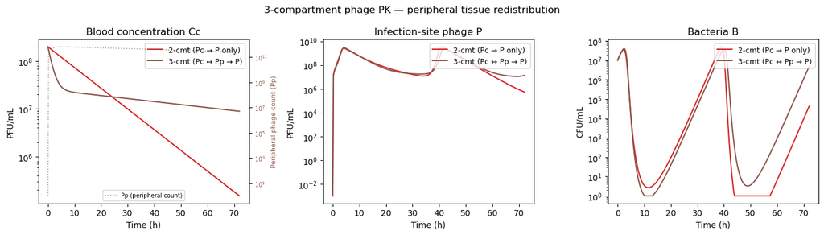

```
Cc at t=2h:  2-cmt = 1.64e+08,  3-cmt = 6.90e+07 PFU/mL  (2.4x lower — alpha-phase to Pp)
Cc at t=5h:  2-cmt = 1.21e+08,  3-cmt = 2.93e+07 PFU/mL
Peak Pp (peripheral): 6.71e+11 phage sequestered in tissues
```

```python
# Add peripheral compartment (k12/k21) to the effect-compartment model from §3
# All other PK parameters are identical — the only change is adding k12/k21.
ppk_3cmt = PhagePKConfig(
    n_phages = 1,
    k_elim   = np.array([0.1]),     # same as ppk_effect (§3)
    k_in     = np.array([0.3]),
    k_out    = np.array([0.2]),
    Vc       = np.array([5000.0]),
    k12      = np.array([0.5]),     # h⁻¹  rapid distribution to peripheral tissues
    k21      = np.array([0.1]),     # h⁻¹  slow redistribution to blood
)
print(f"has_peripheral: {ppk_3cmt.has_peripheral}")  # True

cfg_3cmt = BASE.with_phage_pk(ppk_3cmt).with_dose_schedule(sched_iv).build()
res_3cmt = solve_ode(
    PBIModel(cfg_3cmt, initial_B=B0,
             initial_P=np.array([0.0]), initial_Pc=np.array([0.0])),
    t_end=T_END, dt=0.25,
)

fig, axes = plt.subplots(1, 3, figsize=(14, 4))
Vc_val = ppk_effect.Vc[0]

for res, color, label in [
    (res_effect, "C3", "2-cmt (Pc \u2192 P only)"),
    (res_3cmt,   "C5", "3-cmt (Pc \u2194 Pp \u2192 P)"),
]:
    t = res.time
    axes[0].semilogy(t, np.maximum(res.get("Pc0") / Vc_val, 1.0), color=color, label=label)
    axes[1].semilogy(t, np.maximum(res.get("P0"),            1e-3), color=color, label=label)
    axes[2].semilogy(t, np.maximum(res.get("B0"),            1.0),  color=color, label=label)

# Show peripheral phage (Pp) on right y-axis of the blood panel
ax2 = axes[0].twinx()
ax2.semilogy(res_3cmt.time, np.maximum(res_3cmt.get("Pp0"), 1.0),
             "C5:", alpha=0.6, lw=1.2, label="Pp (peripheral count)")
ax2.set_ylabel("Peripheral phage count (Pp)", color="C5", fontsize=8)
ax2.tick_params(axis="y", labelcolor="C5", labelsize=7)
ax2.legend(fontsize=7, loc="lower center")

for ax, title, ylabel in zip(axes,
        ["Blood concentration Cc", "Infection-site phage P", "Bacteria B"],
        ["PFU/mL",                 "PFU/mL",                 "CFU/mL"]):
    ax.set(xlabel="Time (h)", ylabel=ylabel, title=title)
    ax.legend(fontsize=9, loc="upper right")

plt.suptitle("3-compartment phage PK \u2014 peripheral tissue redistribution")
plt.tight_layout()
plt.show()

# Both models peak at t=0 (bolus); peripheral distribution then lowers Cc in 3-cmt.
t_arr = res_3cmt.time
Cc2 = res_effect.get("Pc0") / Vc_val
Cc3 = res_3cmt.get("Pc0")   / Vc_val
idx_2h = int(np.searchsorted(t_arr, 2.0))
idx_5h = int(np.searchsorted(t_arr, 5.0))
print(f"Cc at t=2h:  2-cmt = {Cc2[idx_2h]:.2e},  3-cmt = {Cc3[idx_2h]:.2e} PFU/mL  "
      f"({Cc2[idx_2h]/max(Cc3[idx_2h], 1e-30):.1f}x lower — alpha-phase to Pp)")
print(f"Cc at t=5h:  2-cmt = {Cc2[idx_5h]:.2e},  3-cmt = {Cc3[idx_5h]:.2e} PFU/mL")
Pp0_arr = res_3cmt.get("Pp0")
print(f"Peak Pp (peripheral): {Pp0_arr.max():.2e} phage sequestered in tissues")
```

## 9 Summary

| Mode | `Vi` | Site equation | Use when |
| --- | --- | --- | --- |
| No PK | — | dose → P directly | Local/topical delivery |
| Effect compartment | `None` | `dP += k_in·Cc − k_out·P` | Site volume unknown/negligible |
| Mass-conserving | array | `dP += k_in·Pc/Vi − k_out·P` | Known site volume; bidirectional exchange needed |
| 3-compartment extension | any | add `k12`, `k21` to any mode above | Realistic IV distribution; biexponential `Cc` |

`Pc` is the phage **amount** (total count) in blood; `Cc = Pc/Vc` is the blood concentration. `DoseEvent(target="phage")` adds to `Pc` when PK is configured and to `P` directly otherwise.

**Next tutorial:** *Antibiotic PK/PD* — adding a companion antibiotic with two-compartment PK and Hill-equation pharmacodynamics.